# H9 RPE YOUNG Sample Analysis

# R Environment Setup

This analysis uses Seurat v3 and its associated workflows.

```r
# All packages are available via CRAN
# Single cell analysis
library(Seurat)

# Plotting functions
library(tidyverse)
library(ggpubr)
library(ggExtra)
```

## Load and process data

```r
input_dir <- "/Volumes/LACIE/RPE_scRNA/PUBLISHED/H9_RPE_YOUNG/outs/filtered_feature_bc_matrix/"
data <- Read10X(input_dir)
seurat_obj <- CreateSeuratObject(data, project = "RPE_scRNA")

# Add metadata
seurat_obj[["condition"]] <- "Control"

seurat_obj[["percent.mt"]] <- PercentageFeatureSet(seurat_obj, pattern = "^MT-")
seurat_obj[["percent.rb"]] <- PercentageFeatureSet(seurat_obj, pattern = "^RPS|^RPL")
```

## Extract metadata

We will use the QC metrics Seurat has calculated for us on object generation.

```r
# Retrieve values to plot from the Seurat object
metadata <- seurat_obj@meta.data
print(metadata[1:10,])
```

```
##                  orig.ident nCount_RNA nFeature_RNA condition percent.mt
## AAACCTGAGACGACGT  RPE_scRNA       5548         1841   Control   4.109589
## AAACCTGAGCACCGCT  RPE_scRNA       4062         1693   Control   5.440670
## AAACCTGAGCTCTCGG  RPE_scRNA       5325         1587   Control   3.568075
## AAACCTGAGCTGCGAA  RPE_scRNA       2983         1255   Control   4.626215
## AAACCTGAGCTGTCTA  RPE_scRNA       9559         2446   Control   2.531646
## AAACCTGAGTCAATAG  RPE_scRNA       9173         2589   Control   4.872997
## AAACCTGCAACACGCC  RPE_scRNA       3206         1204   Control   3.836556
## AAACCTGCAAGAGTCG  RPE_scRNA       6949         1831   Control   4.590589
## AAACCTGCAAGCCTAT  RPE_scRNA       2839          998   Control   3.205354
## AAACCTGCAATTGCTG  RPE_scRNA       2018          864   Control   3.617443
##                  percent.rb
## AAACCTGAGACGACGT   31.88536
## AAACCTGAGCACCGCT   25.43082
## AAACCTGAGCTCTCGG   39.15493
## AAACCTGAGCTGCGAA   30.00335
## AAACCTGAGCTGTCTA   37.71315
## AAACCTGAGTCAATAG   33.78393
## AAACCTGCAACACGCC   35.49595
## AAACCTGCAAGAGTCG   44.42366
## AAACCTGCAAGCCTAT   39.62663
## AAACCTGCAATTGCTG   29.13776
```

## Quality control

```r
calcThreshold <- function(x,
                          nmads = 3,
                          type = c("both", "lower", "upper"),
                          na.rm = FALSE){
    med_val <- stats::median(x, na.rm = na.rm)
    mad_val <- stats::mad(x, center = med_val, na.rm = na.rm)
    upper_limit <- med_val + nmads * mad_val
    lower_limit <- med_val - nmads * mad_val

    if (type == "lower"){
      return(lower_limit)
    } else if (type == "upper") {
      return(upper_limit)
    } else(
      return(list(lower_limit, upper_limit))
    )
}
```

We will use this function to generate thresholds for the number of UMIs per cell. We have to convert the counts to log10 for this to work. We can then convert this back afterwards.

```r
# Use function to calculate 3 MAD value of total UMI
nCount_lower_threshold <- calcThreshold(log10(metadata$nCount_RNA),
                                        nmads = 3, type = "lower")
nCount_upper_threshold <- calcThreshold(log10(metadata$nCount_RNA),
                                        nmads = 3, type = "upper")

# Use function to calculate 3 MAD value of features
nFeature_lower_threshold <- calcThreshold(log10(metadata$nFeature_RNA),
                                        nmads = 3, type = "lower")
nFeature_upper_threshold <- calcThreshold(log10(metadata$nFeature_RNA),
                                        nmads = 3, type = "upper")

# Convert to original value (unlog scale)
nCount_lower_threshold <- 10^(nCount_lower_threshold)
nCount_upper_threshold <- 10^(nCount_upper_threshold)
nFeature_lower_threshold <- 10^(nFeature_lower_threshold)
nFeature_upper_threshold <- 10^(nFeature_upper_threshold)
```

We can now review the cutoffs on our plots, in addition to the percentage of mitochondrial and ribosomal-associated transcription.

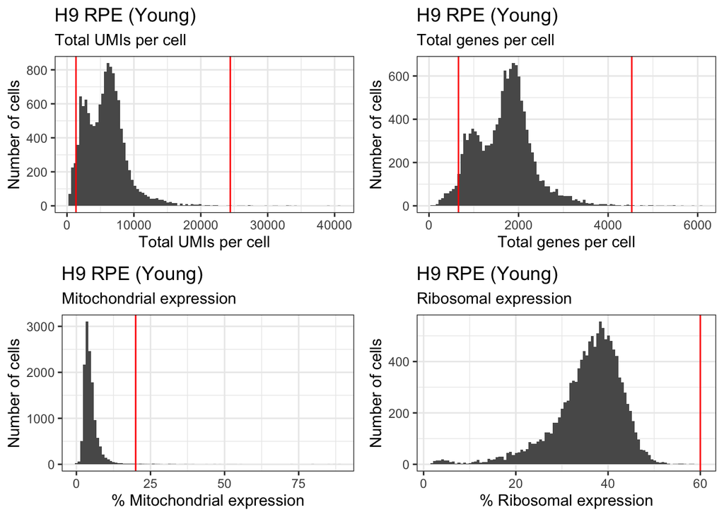

```r
# Generate plots
ncount_hist <- ggplot(metadata, aes(nCount_RNA)) + geom_histogram(bins = 100) +
  theme_bw() + geom_vline(xintercept = nCount_lower_threshold, color = "red") +
  geom_vline(xintercept = nCount_upper_threshold, color = "red") +
  ggtitle("H9 RPE (Young)", subtitle = "Total UMIs per cell") +
  xlab("Total UMIs per cell") + ylab("Number of cells")

nfeature_hist <- ggplot(metadata, aes(nFeature_RNA)) +
  geom_histogram(bins = 100) +
  theme_bw() + geom_vline(xintercept = nFeature_lower_threshold, color = "red") +
  geom_vline(xintercept = nFeature_upper_threshold, color = "red") +
  ggtitle("H9 RPE (Young)", subtitle = "Total genes per cell") +
  xlab("Total genes per cell") + ylab("Number of cells")

mt_hist <- ggplot(metadata, aes(percent.mt)) + geom_histogram(bins = 100) +
  theme_bw() + geom_vline(xintercept = 20, color = "red") +
  ggtitle("H9 RPE (Young)", subtitle = "Mitochondrial expression") +
  xlab("% Mitochondrial expression") + ylab("Number of cells")

rb_hist <- ggplot(metadata, aes(percent.rb)) + geom_histogram(bins = 100) +
  theme_bw() + geom_vline(xintercept = 60, color = "red") +
  ggtitle("H9 RPE (Young)", subtitle = "Ribosomal expression") +
  xlab("% Ribosomal expression") + ylab("Number of cells")

ggarrange(ncount_hist, nfeature_hist, mt_hist, rb_hist, ncol = 2, nrow = 2)
```

We also need to review all these metrics in the context of each other.

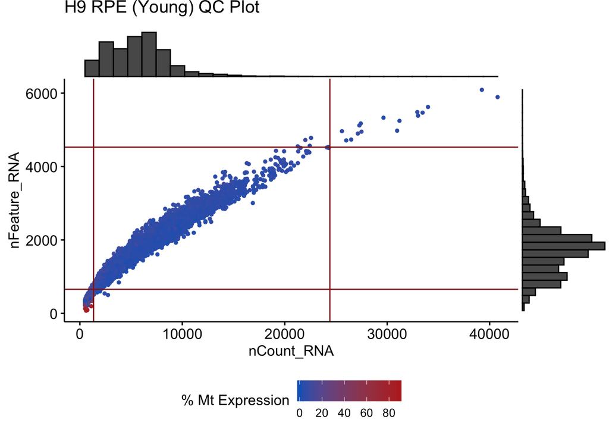

```r
count_feature_plot <- ggscatter(metadata, x = "nCount_RNA",
                                y = "nFeature_RNA",
                                color = "percent.mt", size = 1,
                                title = "H9 RPE (Young) QC Plot") +
  geom_hline(yintercept = nFeature_lower_threshold, color = "#94221f") +
  geom_hline(yintercept = nFeature_upper_threshold, color = "#94221f") +
  geom_vline(xintercept = nCount_lower_threshold, color = "#94221f") +
  geom_vline(xintercept = nCount_upper_threshold, color = "#94221f") +
  gradient_color(c("#1565C0", "#b92b27"))
count_feature_plot <- ggpar(count_feature_plot,
                            legend = "bottom", legend.title = "% Mt Expression")
count_feature_plot <- ggMarginal(count_feature_plot, type = "histogram")
count_feature_plot
```

```r
# Original number of cells
ncells1 <- ncol(seurat_obj)

# Filter poor quality cells from dataset
seurat_obj <- subset(seurat_obj, nCount_RNA > nCount_lower_threshold &
                       nCount_RNA < nCount_upper_threshold &
                       nFeature_RNA > 220 &
                       nFeature_RNA < 5000 &
                       percent.mt < 20 &
                       percent.rb < 60)

ncells2 <- ncol(seurat_obj)
ncelldiff <- ncells1 - ncells2
print(sprintf("%d cells filtered from dataset.", ncelldiff))
```

```
## [1] "511 cells filtered from dataset."
```

## Normalisation

```r
seurat_obj <- SCTransform(seurat_obj,
                          vars.to.regress = c("percent.mt", "percent.rb"),
                          conserve.memory = TRUE, verbose = FALSE)
```

## Dimensionality reduction

```r
# Principal component analysis
seurat_obj <- RunPCA(seurat_obj, verbose = FALSE)

# UMAP
seurat_obj <- RunUMAP(seurat_obj, dims = 1:30, umap.method = "uwot")
```

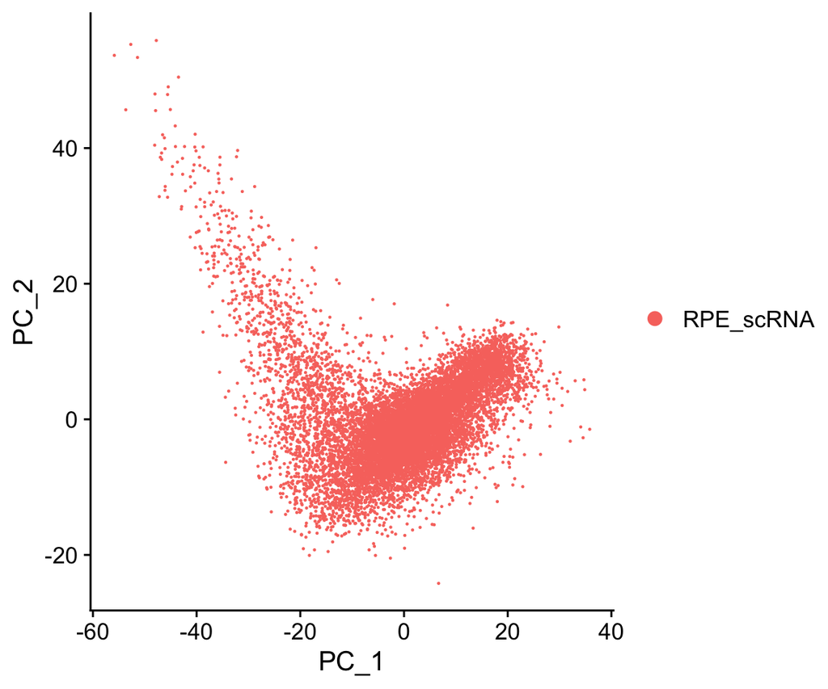

```r
DimPlot(seurat_obj, reduction = "pca")
```

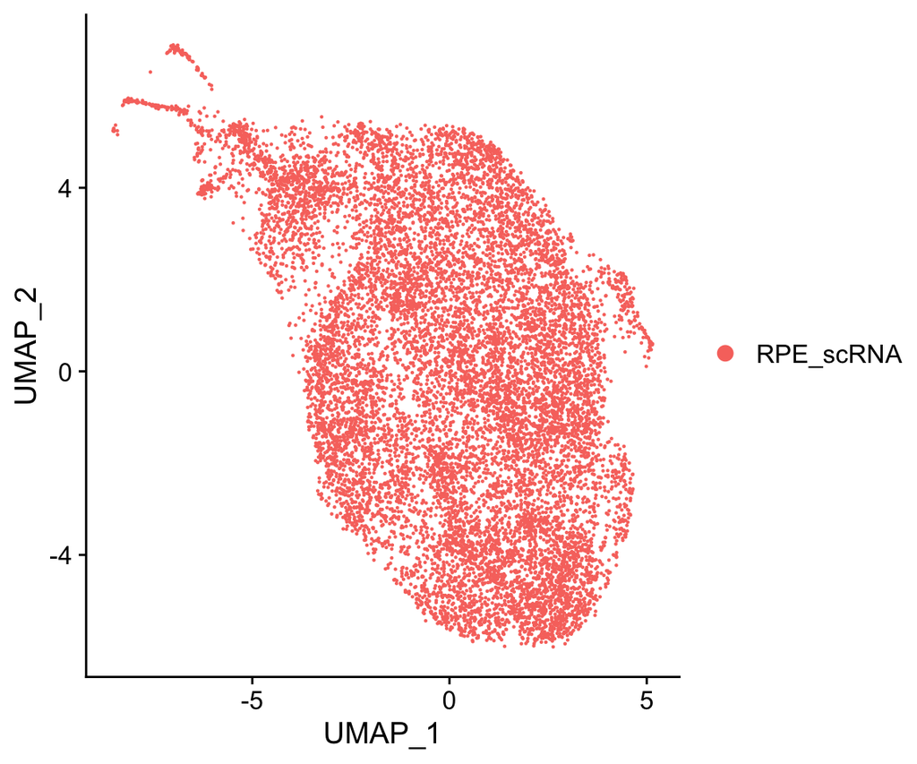

```r
DimPlot(seurat_obj, reduction = "umap")
```

## Clustering

```r
seurat_obj <- FindNeighbors(seurat_obj, dims = 1:30)
windows <- c(seq(0, 1, by = 0.1))

for (res in windows){
  seurat_obj <- FindClusters(seurat_obj, resolution = res, verbose = FALSE)
}
```

Build a clustree to review cluster results at different resolutions.

```r
library(clustree)
```

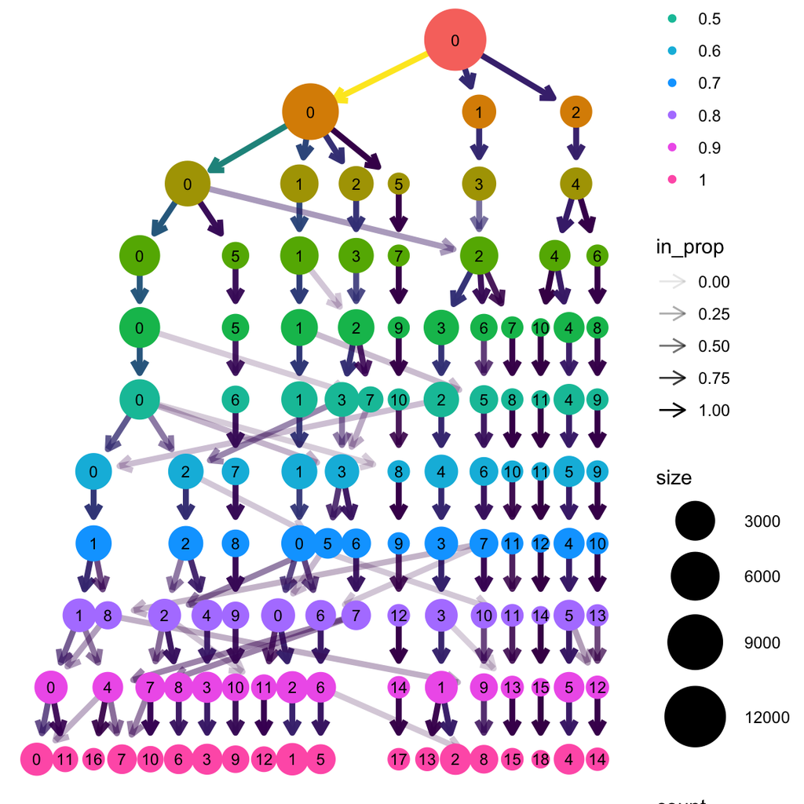

```r
clustree_plot <- clustree(seurat_obj, prefix = "SCT_snn_res.")
clustree_plot
```

The left side of the tree show the cluster identities are unstable, while the right branch is very stable. Stability of the branches are represented by the arrows moving from node to node. The goal is to minimise the number of unclassified cells that are in cluster 0.

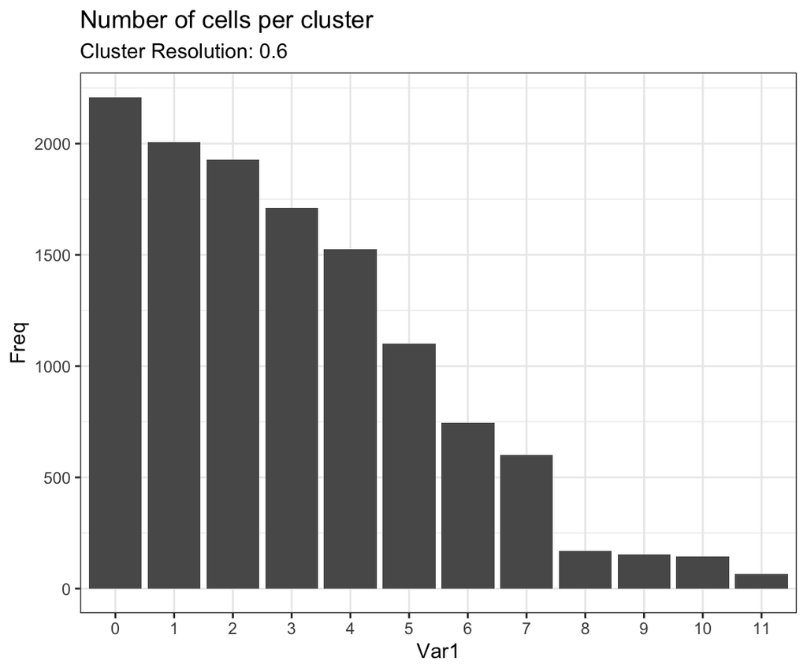

```r
metadata <- FetchData(seurat_obj, vars = c("seurat_clusters", "SCT_snn_res.0.6"))
res_counts <- as.data.frame(table(metadata$SCT_snn_res.0.6))
res_hist <- ggplot(res_counts, aes(x = Var1, y = Freq)) +
  geom_bar(stat = "identity") + theme_bw() +
  ggtitle("Number of cells per cluster", subtitle = "Cluster Resolution: 0.6")
res_hist
```